```python
import pylab as pl
from  numpy.random import normal
import numpy as np
import healpy as hp
from scipy  import  signal
from scipy.signal import periodogram

from pylab import cm
cmap = cm.get_cmap('RdYlBu')
cmap.set_under('w')
import scipy.stats as spt
```

```python
from IPython.display import HTML

HTML('''<script>
code_show=true;
function code_toggle() {
 if (code_show){
 $('div.input').hide();
 } else {
 $('div.input').show();
 }
 code_show = !code_show
}
$( document ).ready(code_toggle);
</script>
<form action="javascript:code_toggle()"><input type="submit" value="Click here to toggle on/off the raw code."></form>''')
```

# 1. Summary of latest results

08/08/2019

In [my previous posting](http://giuspugl.github.io/reports/GainDrifts_20190725.html), I've chosen 3 parameters needed to inject gain systematics and 2 parameters to mitigate them into our TOAST simulations: $(f_k, f_{lpf} , f_c, \tau_g, \sigma_g ) $, $f_k$ is the knee freq. for the 1/f dependence of gain drift, $f_{lpf}$ the low freq. cutoff of the drift, $\sigma_g$ is the amplitude of the fluctuations, $\tau_g$ the time scale adopted to estimate the gain by regressing the TOD of each detector by a template, $f_c$ high freq. cut-off in case we want to high pass filter the data.

I've shown that the regression technique was able to track both gain mismatches ( i.e. random fluctuations constant during a given timescale $\tau_g$ ) and gain drifts ( slowly varying drifting signal with a $1/f$ dependence ) if :

- we high pass filter the data with a low frequency cut-off $f_c > f_{\tau} = \tau_g^{-1} $
- for signal only sims the gain estimates don't depend on $\sigma_g> 10^{-4} $ ( even for signal only sims )

The next step forward is to add noise to the signal and assess how it affects the gain estimates.

### Simulation setups

Drift Parameters:

- $f_c = 50$ mHz
- $ \sigma_g= 10^{-6}$
- $\tau_g = 1, 10 $ min
- the gain drift has a 1/f dependence ( with $ f_k = 150 $ mHz ) and it has been low pass filtered with a cut off freq. of 1 mHz, so that all the gain fluctuations below the ~ 10 minutes time scale are filtered out.

Toast Params ( values from latest [Litebird-IMO wiki page](https://wiki.kek.jp/pages/viewpage.action?pageId=108104267):

- Detector pairs: 2
- frequency band: 90 GHz
- T_obs : 1 yr
- sampling freq: 20 Hz
- precession period :96.1803 min
- spin period: 10 min
- Noise simulated : white
- NET : 30 uK sqrt(s)
- HWP : False
- spin angle : 50
- precession angle :45
- MADAM destriper (baseline=60 sec)
- Input maps: Monopole, Dipole, CMB T , Galactic emission @90 GHz

The procedure to mitigate gain mismatches is performed on each chunck (related to $\tau$) of time samples $d_{t , t+\tau}$ of a given detector:

1. Apply a high-pass filter to $d_{t , t+\tau} $ with cutoff frequency $f_{c}=50$ mHz
   1. Regress $d_{t , t+\tau} $ against signal-only template $T$ and estimate the regression slope $\hat{g}$ as $$ \hat{g} = \frac { T^{t} d } { T^{t} T } $$
   2. Mitigate the leakage, dividing $d_{t , t+\tau} $ by $\hat{g}$
   3. Estimate maps after mitigation

```python
def band_pass_filter(fcutoff, fsampl, data, filtermode='high' ):
    alpha=2. *fcutoff  /fsampl
    padlength = np.int_( fsampl/fcutoff )
    b, a = signal.butter(4, alpha , filtermode)
    filtsignal=  signal.filtfilt(b, a, data,padtype='constant',  padlen=padlength  )
    return filtsignal

def bin_gains(tau, fs,obs,  g) :
    sizech = pl.int_( tau *fs)  ; nch =pl.int_(  obs *fs*3600  /sizech)
    gb = pl.zeros(nch)
    for i in range (nch):
        gb[i] =g[slice(i*sizech, (i+1)*sizech)] .mean()
    return gb
```

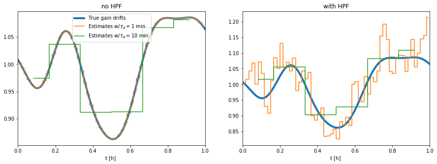

```python
folder = '/Users/peppe/work/satellite_sims/sigmag_1em2/'
obs=1.

tau1=60; fs=20;
tau10 =tau1*10.
g=pl.load(folder+ 'gain_drift.npy')[0,:] ;

gb1 =bin_gains (tau1, fs ,obs,  g+1 )
gb10 =bin_gains (tau10, fs ,obs,  g+1 )

ge1=pl.load(folder+ 'gains_coeff_60.npy')[:60]
ge10 = pl.load(folder+ 'gains_coeff_600.npy')[:6]
te1 = ( (pl.arange(len( ge1) ) )  *tau1  + (tau1/2) ) /3600.
te10 = ( (pl.arange(len( ge10) ) )  *tau10  + (tau10/2) ) /3600.
gb1 =bin_gains (tau1, fs ,obs,  g+1 )
gb10 =bin_gains (tau10, fs ,obs,  g+1 )
s2t1= spt.linregress(ge1, gb1)[2]
s2t10= spt.linregress(ge10, gb10)[2]

t = pl.arange(len(g) )/fs/3600.
pl.figure(figsize=(15,5))
pl.subplot(121)
pl.title('no HPF')
pl.xlabel('t [h] ')
pl.plot(t,g  +1, lw=4 , label='True gain drifts ' ) ;
pl.step(te1,ge1 , where='mid' , label=r'Estimates w/$\tau_g =1$ min ');
pl.step(te10,ge10 , where='mid', label=r'Estimates w/$\tau_g =10$ min ')
pl.xlim([0,1])
pl.legend()
pl.subplot(122)
pl.title('with HPF')

folder = '/Users/peppe/work/satellite_sims/sigmag_1em2/hpf/'
ge1=pl.load(folder+ 'gains_coeff_60.npy')[:60]
ge10 = pl.load(folder+ 'gains_coeff_600.npy')[:6]
pl.xlabel('t [h] ')
pl.plot(t,g  +1, lw=4 , label='True gain drifts ' ) ;
pl.step(te1,ge1 , where='mid' , label=r'Estimates w/$\tau_g =1$ min ');
pl.step(te10,ge10 , where='mid', label=r'Estimates w/$\tau_g =10$ min ')
pl.xlim([0,1])


s2t1h= spt.linregress(ge1, gb1)[2]
s2t10h= spt.linregress(ge10, gb10)[2]
```

**Fig1**: (left) Gain estimates during 1 h period, ( solid thick blue) the underlying gain drift with $\sigma_g=10^{-2}$, ( green) and (orange) steps are the gain estimates performed respectively during 10 and 1 minute on data without applying the high-pass filter. (right) as in left panel with gain estimates performed with high-pass filtered data.

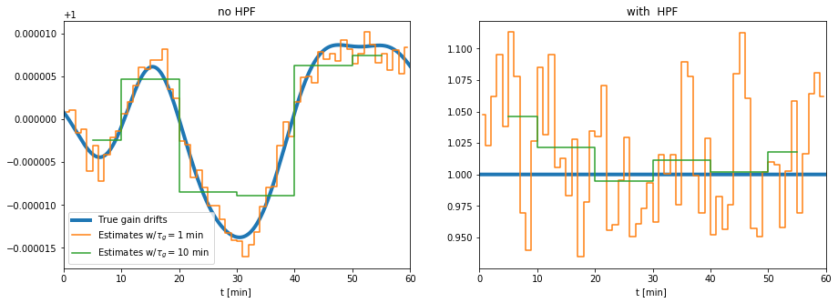

```python
folder = '/Users/peppe/work/satellite_sims/sigmag_1em6/'
obs=1.

tau1=60; fs=20;
tau5 = tau1 *5
tau10 =tau1*10.
g=pl.load(folder+ 'gain_drift.npy')[0,:] ;
ge1=pl.load(folder+ 'gains_coeff_60.npy')[:60]
#ge5=pl.load(folder+ 'gains_coeff_300.npy')[:12]
ge10 = pl.load(folder+ 'gains_coeff_600.npy')[:6]
gb1 =bin_gains (tau1, fs ,obs,  g+1 )
gb10 =bin_gains (tau10, fs ,obs,  g+1 )
s4t1= spt.linregress(ge1, gb1)[2]
s4t10= spt.linregress(ge10, gb10)[2]

te1 = ( (pl.arange(len( ge1) ) )  *tau1  + (tau1/2) ) /60.
te10 = ( (pl.arange(len( ge10) ) )  *tau10  + (tau10/2) ) /60.
te5 = ( (pl.arange(len( ge5) ) )  *tau5  + (tau5/2) ) /60.

t = pl.arange(len(g) )/fs/60.
pl.figure(figsize=(15,5))
pl.subplot(121)
pl.xlabel('t [min] ')

pl.plot(t,g  +1, lw=4 , label='True gain drifts ' ) ;
pl.step(te1,ge1 , where='mid' , label=r'Estimates w/$\tau_g =1$ min ');

pl.step(te10,ge10 , where='mid', label=r'Estimates w/$\tau_g =10$ min ')
pl.title('no HPF')


pl.xlim([0,60])
pl.legend()
pl.subplot(122)
pl.title('with  HPF')

folder = '/Users/peppe/work/satellite_sims/sigmag_1em4/hpf/'
ge1=pl.load(folder+ 'gains_coeff_60.npy')[:60]
ge10 = pl.load(folder+ 'gains_coeff_600.npy')[:6]
#ge5=pl.load(folder+ 'gains_coeff_300.npy')[:12]
pl.xlabel('t [min] ')
pl.plot(t,g  +1, lw=4 , label='True gain drifts ' ) ;
pl.step(te1,ge1 , where='mid' , label=r'Estimates w/$\tau_g =1$ min ');
pl.step(te10,ge10 , where='mid', label=r'Estimates w/$\tau_g =10$ min ')

pl.xlim([0,60])

s4t1h= spt.linregress(ge1, gb1)[2]
s4t10h= spt.linregress(ge10, gb10)[2]
```

**Fig2**: (left) Gain estimates during 1 h period, ( solid thick blue) the underlying gain drift with $\sigma_g=10^{-6}$, ( green) and (orange) steps are the gain estimates performed respectively during 10 and 1 minute on data without applying the high-pass filter. (right) as in left panel with gain estimates performed with high-pass filtered data.

```python
folder = '/Users/peppe/work/satellite_sims/sigmag_1em6/'

g=pl.load(folder+ 'gain_drift.npy')[0,:] ;
ge1=pl.load(folder+ 'gains_coeff_60.npy')[:60]
ge10 = pl.load(folder+ 'gains_coeff_600.npy')[:6]
gb1 =bin_gains (tau1, fs ,obs,  g+1 )
gb10 =bin_gains (tau10, fs ,obs,  g+1 )
s6t1= spt.linregress(ge1, gb1)[2]
s6t10= spt.linregress(ge10, gb10)[2]

folder = '/Users/peppe/work/satellite_sims/sigmag_1em6/hpf/'
ge1=pl.load(folder+ 'gains_coeff_60.npy')[:60]
ge10 = pl.load(folder+ 'gains_coeff_600.npy')[:6]

s6t1h= spt.linregress(ge1, gb1)[2]
s6t10h= spt.linregress(ge10, gb10)[2]
```

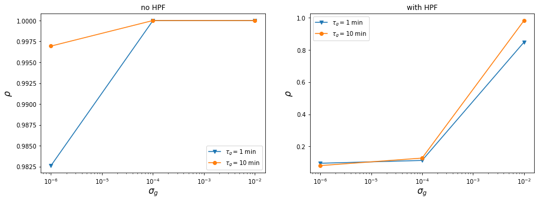

```python
%matplotlib inline
pl.figure(figsize=(15,5))

pl.subplot(121)
pl.title('no HPF')

sigmas = pl.logspace(-6,-2,3)
pl.semilogx(sigmas, [s6t1,s4t1,s2t1],'v-', label=r'$\tau_g =1 $ min')
pl.semilogx(sigmas, [s6t10,s4t10,s2t10],'o-', label=r'$\tau_g =10 $ min')
pl.xlabel(r'$\sigma_g$', fontsize=15); pl.ylabel(r'$\rho$', fontsize=15 )
pl.legend()
pl.subplot(122)
pl.title('with HPF')

pl.semilogx(sigmas, [s6t1h,s4t1h,s2t1h],'v-', label=r'$\tau_g =1 $ min')
pl.semilogx(sigmas, [s6t10h,s4t10h,s2t10h],'o-', label=r'$\tau_g =10 $ min')
pl.legend()

pl.xlabel(r'$\sigma_g$', fontsize=15); pl.ylabel(r'$\rho$', fontsize=15 )
```

**Fig3** Correlation coefficient between gain estimates and binned underlying gain drifts as a function of $\sigma_g$, for the case without (left) and with (right) high-pass filter.

As it can be noticed in **figg 1,2,3**, the effect of noise on the gain estimate is highly dependent by $\sigma_g$, i.e. the amplitude of gain fluctuations, the lower the noisier are the estimates and the less we are able to track the underlying fluctuations. This is mostly observed when we regress the high-pass filtered data against CMB T anisotropies, because the signal-to-noise ratio is not very high to extract the gain drift with $\sigma_g<10^{-2}$ from a noisy signal. Notice that we see a similar effects on unfiltered data, though on a lower amplitude, i.e. $\sigma_g<10^{-6}$.

# 2. Assessing effects at TOD level

We therefore focus on a fairly low $\sigma_g=10^{-4}$ and check the effect on the TOD data before and after the gain mitigation. As a figure of merit, we estimate the fractional difference $\Delta$ defined as: $$ \Delta = \frac{d-s}{s} $$ where $s$ is the input signal and $d$ is the detector TOD, encoding signal, gain systematics and noise.

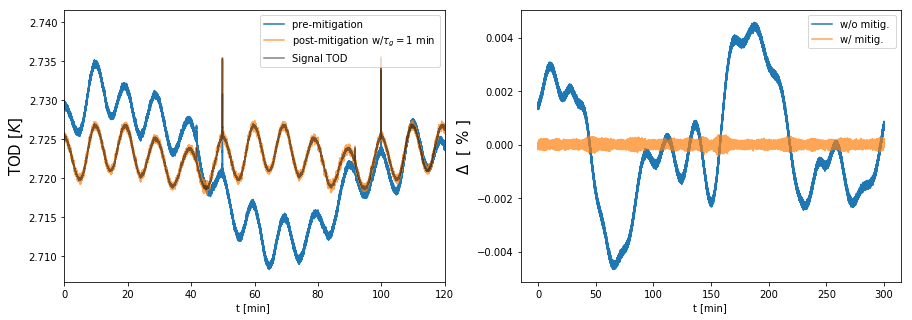

```python
folder = '/Users/peppe/work/satellite_sims/out/'
pl.figure(figsize=(15,5))

dri =pl.load(folder+'drifttod.npy')
sig=pl.load(folder+'signaltod.npy')

mit1=pl.load(folder+'mittod_60.npy')
t = pl.arange(len( dri[0,:]) )/fs/3600.
pl.subplot(121)
pl.plot(t*60 , dri[0,:]  , label='pre-mitigation ' )

pl.plot(t*60, mit1[0,:] , alpha=.7,label=r'post-mitigation w/$\tau_g =1$ min')

pl.plot(t*60, sig[0,0,:] ,'k', alpha=.5 , label='Signal TOD')
pl.xlim([0,120])
pl.xlabel('t [min] ')
pl.ylabel('TOD ['+r'$K  $]', fontsize=15)

pl.legend()
#pl.plot(t*60, mit5[0,:] , alpha=.5)

#pl.plot(t*60, mit10[0,:] , alpha=.5)
pl.subplot(122)
pl.plot(t*60 , (dri[0,:] - sig[0,0,:] )/sig[0,0,:], label='w/o mitig. ')
pl.plot(t*60, (mit1[0,:]- sig[0,0,:])/sig[0,0,:] , label='w/ mitig. ', alpha=.7)
pl.xlabel('t [min] ')
pl.ylabel(r'$ \Delta$  [ % ]', fontsize=15)
pl.legend()

from scipy.signal import periodogram



f,pd= periodogram(dri[0,:] , fs=fs, scaling='density')

f,pm1  = periodogram(mit1[0,:] , fs=fs, scaling='density');
f,ps  = periodogram( sig[0,0,:] , fs=fs, scaling='density')
```

**Fig 4** : (left) 2 hours of simulated data, (solid black) signal-only,(solid blue) detector TOD without mitigating the systematics, (solid orange) detector TOD after mitigation has been applied every minute of data. (right) Fractional difference $\Delta$ estimated with TODs shown in the left panel.

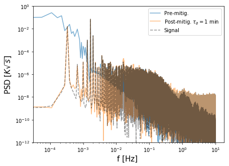

```python
pl.figure(figsize=(15,5))
pl.subplot(121)
pl.ylabel('PSD ['+r'$K \sqrt{s}$]', fontsize=15)
pl.xlabel('f [Hz] ', fontsize=15);

pl.loglog(f, pd, alpha=.6, label ='Pre-mitig. ')


#pl.loglog(f, pm10, alpha=.6, label ='Post-mitig. 'r'$\tau_g =10$ min ')

pl.legend()
pl.ylim([1e-12,1])

#pl.subplot(122)
pl.ylim([1e-12,1])
pl.xlabel('f [Hz] ', fontsize=15);

#pl.loglog(f , ps ,'k--', alpha=.4, label='Signal' )

pl.loglog(f, pm1, alpha=.5, label ='Post-mitig. '+r'$\tau_g =1$ min ')

pl.loglog(f , ps ,'k--', alpha=.4 , label='Signal')
pl.legend()
```

**Fig5** (blue) PSD of TOD (shown in Fig.4) encoding the astrophysical signal convolved with gain drifts. (orange) PSD of TODs with gain mitigation applied every minute, (dashed black ) PSD of signal only time stream.

Notice that the 1/f component signal is uinquely due to gain drift. By comparing the two PSDs in (dashed black ) and (orange), we observe that the gain drift is very well mitigated. At high frequencies, $>1 $ Hz, white noise starts to be the dominant component in both the pre and post mitigation samples.

# 3. Summary

- We 've tested our systematics assessment including white noise in our simulations
- High-pass filtered data are very much affected by noise for small values of $\sigma_g $, < 1%. Vice versa without high pass filtering the TODs we can track gain drifts even at very small fluctuations $\sigma_g< 10^{-6}$.
- The mitigation reduces the $f_{knee}$ so that it makes negligible the impact of 1/f noise due to gain drift.